# Numpy

```python
from IPython.display import Image
```

과학적 계산을 위한 핵심 라이브러리

1. Numerical Python
2. 고성능 수치 게산을 위해 제작
3. 벡터및 행렬에 편리
4. 선형대수 관련 기능

[figure not shown]

###### Python의 list와 narray차이

python list는 포인터 배열 따라서 narray가 속도가 빠름

[figure not shown]

```python
import numpy as np

np.__version__  # numpy 를 불러오고 버전확인
```

```
'1.18.5'
```

```python
arr=np.array([1,3,5,7,8])
print(arr)
```

```
[1 3 5 7 8]
```

### dtype(데이터 타입)

데이터 타입은 python에서의 타입과 numpy에서 제공하는 타입으로 사용된다.

#### 파이썬 타입 (built-in python type)

##### https://numpy.org/doc/stable/reference/arrays.dtypes.html#arrays-dtypes

[figure not shown]

#### numpy의 데이터 타입

##### https://numpy.org/doc/stable/user/basics.types.html#array-scalars

[figure not shown]

스칼라(scalar): 하나의 숫자로만 이루어진 데이터

벡터(vector) : 일차원 배열 (숫자가 순서대로 모여있는것)

행렬(matrix) : 복수차원을 가지는 데이터가 여러개 있는 경우

3차원 이상 배열을 tensor

```python
#float형 3*2 행렬
np.array([10,20,30,40,50,60],dtype=np.float16).reshape(3,2)
```

```
array([[10., 20.],
       [30., 40.],
       [50., 60.]], dtype=float16)
```

```python
arr2=np.array([(i, i*3) for i in range(1,10)])
print(arr2)
```

```
[[ 1  3]
 [ 2  6]
 [ 3  9]
 [ 4 12]
 [ 5 15]
 [ 6 18]
 [ 7 21]
 [ 8 24]
 [ 9 27]]
```

```python
#3*3 행렬만들기
import numpy as np
arr3=np.array([1,2,3,4,5,6,7,8,9]).reshape(3,3)
print(arr3.shape)
print(arr3)
```

```
(3, 3)
[[1 2 3]
 [4 5 6]
 [7 8 9]]
```

```python
np.arange(12).reshape(3,4) #0~11의 값으로 3*4 행렬을 만듬
```

```
array([[ 0,  1,  2,  3],
       [ 4,  5,  6,  7],
       [ 8,  9, 10, 11]])
```

```python
arr=np.array([[index,index*3]  for index in [1,3,5]])
print(arr,arr.shape)
```

```
[[ 1  3]
 [ 3  9]
 [ 5 15]] (3, 2)
```

```python
## astype 함수를 사용한 데이터 타입 변환
arr_int = np.array([1,2,3,4]) # 정수형 데이터 배열 생성
arr_int.dtype
arr_float = arr_int.astype(np.float64) # 실수형 데이터 배열로 변환
print(arr_float.dtype)
print(arr_float)
```

```
float64
[1. 2. 3. 4.]
```

### 전치(transpose)

행렬의 주 대각선을 기준으로 대칭되는 요소끼리 뒤바꾸는 것  
이를 전치라고 하며 행렬을 전치하기 위해선, 간단하게 배열 객체의 ‘T’ 속성을 사용

행과 열을 변경

strides :Tuple of bytes to step in each dimension when traversing an array.  
(dimensions 간의 간격, 앨리먼트간의 간격) 으로 표시함

https://numpy.org/doc/1.18/reference/generated/numpy.ndarray.strides.html#numpy-ndarray-strides

```python
import numpy as np
a=np.array([1,2,3,4,5,6])
print(a.strides)
```

```
(4,)
```

```python
a=np.arange(10).reshape(5,2)
a.strides
```

```
(8, 4)
```

```python
a=np.array([1,2,3,4,5,6],dtype=int).reshape(3,2)

b=a.T

print("a:{0}, a.strides :{1}".format(a , a.strides))  # strides:  dimension간격   (8,4)
print("b:{0}, b.strides:{1}".format(b, b.strides) )  #(8,4)전치 행렬(transposed matrix) ->(4,8)
```

```
a:[[1 2]
 [3 4]
 [5 6]], a.strides :(8, 4)
b:[[1 3 5]
 [2 4 6]], b.strides:(4, 8)
```

```python
a=np.array(range(12),dtype=int).reshape(3,4)

b=a.T

print(a , a.strides)  # strides:  dimension간격   (16,4)
print(b, b.strides)   #(16,4)전치 행렬(transposed matrix) ->(4,16)
```

```
[[ 0  1  2  3]
 [ 4  5  6  7]
 [ 8  9 10 11]] (16, 4)
[[ 0  4  8]
 [ 1  5  9]
 [ 2  6 10]
 [ 3  7 11]] (4, 16)
```

```python
a= np.array([[1,2,3], [4,5,6]], np.int32)
a.shape   #행렬 (2,3)
a.dtype.name  # 자료타입  'int32'
a.ndim   #2차원 => python에서는 차원의 개수를 랭크
a.size  #배열의 모든 요소들의 개수
a.itemsize #배열의 각 요소의 바이트에서의 사이즈
```

```
4
```

```python
np.arange(10)  #0에서부터 10(exclusive)까지
np.arange( 10, 30, 1)  # 10에서 20(exclusive) 1증가
np.arange(10,20, 3)     #10에서 20(exclusive) 3씩 증가
```

```
array([10, 13, 16, 19])
```

```python
a=np.empty([4,2])  # 4*2배열을 초기화 하지 않음
print(a)
```

```
[[0.000e+000 0.000e+000]
 [0.000e+000 0.000e+000]
 [0.000e+000 3.656e-321]
 [0.000e+000 0.000e+000]]
```

zeros는 각 요소를 0으로 초기화 할떄

```python
a=np.zeros([3,2])  #0으로 초기화
print(a)
```

```
[[0. 0.]
 [0. 0.]
 [0. 0.]]
```

```python
t=np.ones([2,3,4],dtype=np.int16)  #1로 초기화
t.ndim
```

```
3
```

```python
np.full((2, 5), 3, dtype=np.int)  # 2*5  다차원 배열의 요소가 모두 3으로 채움
```

```
array([[3, 3, 3, 3, 3],
       [3, 3, 3, 3, 3]])
```

#### random : 난수 지정

#### https://numpy.org/devdocs/reference/random/index.html?highlight=random#module-numpy.random

```python
from numpy.random import default_rng
rng = default_rng(1)

rng.random([3,4])
```

```
array([[0.51182162, 0.9504637 , 0.14415961, 0.94864945],
       [0.31183145, 0.42332645, 0.82770259, 0.40919914],
       [0.54959369, 0.02755911, 0.75351311, 0.53814331]])
```

shuffle : 각 element를 random으로 섞을때

```python
import random
import numpy as np

data=['a','b','c','e']

random.shuffle(data)
data
```

```
['a', 'e', 'c', 'b']
```

```python
from random import Random
import time

print(time.strftime('%Y- %B - %d, %H: %M : %S'.format(time.time)))

rnd=Random(time.time)
for i in range(0,4):
    print(rnd.random())
```

```
2020- December - 06, 11: 00 : 17
0.8488908353532081
0.959282191013688
0.24595053583450555
0.643068420473004
```

choice(n,p ) n개중 p개를 choice 할때 사용  
choice(3,2 ) : 0,1,2 중 random값 2개 choice

```python
rng = np.random.default_rng()

rng.choice(3,2)  #0,1,2 중 random값 2개 choice
rng.choice(10, [5,2])
```

```
array([[9, 4],
       [2, 1],
       [6, 9],
       [9, 0],
       [6, 7]], dtype=int64)
```

```python
# exp(n)   자연상수(e) n승
data = np.arange(3)
np.exp(data)
```

```
array([1.        , 2.71828183, 7.3890561 ])
```

#### binomial:이항분포에서 표본 추출

https://numpy.org/devdocs/reference/random/generated/numpy.random.binomial.html?highlight=binomial#numpy.random.binomial

random.binomial(n, p, size=None)

연속된 n번의 독립시행에서 각 시행이 확률 p를 가질때 이산확률 분포  
=> 베르누이 시행

[figure not shown]

```python
import numpy as np
k, prob = 2, 0.5    # number of trials, probability of each trial
np.sum(np.random.binomial(k, prob,7)==2)/7   #0,1,2  test를 7번 반복
```

```
0.2857142857142857
```

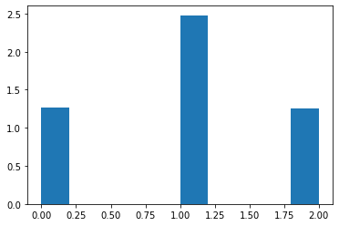

```python
import matplotlib.pyplot as plt
import numpy as np

s=np.random.binomial(2, 0.5,10000)
count, bins, ignored = plt.hist(s, 10, density=True)
# bin :막대영역 채우는 정도(정수일 경우 정수범위+1 범위로 나눈 값으로 채움)
```

연속 2번의 독립시행에서 각 확률이 0.5인 경우  
p(x=0), p(x=1), p(x=2)

#### normal:정규분포(가우시안)에서 표본 추출

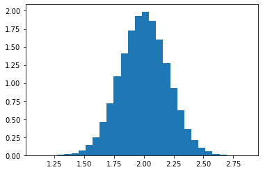

```python
import matplotlib.pyplot as plt
import numpy as np

mu, sigma=2, 0.2  # mean and standard deviation
s=np.random.normal(mu, sigma, 100000)
count, bins, ignored = plt.hist(s, 30, density=True)
```

### 연산

np.add(a,b) : a+b

np.subtract(a,b) : a-b

p.multiply(a,b) : a*b

np.divide(a,b) : a /b

```python
#연산
a=np.array([20,30,40,50])
b=np.arange(1,9,2)  #[1,3,5,7]

d1=a+b
print(d1)
```

```
[21 33 45 57]
```

```python
d2=a-b
d3=a*b  #같은 행렬끼리 곱함
d4=a/b

print(d2, d3, d4)
print(np.subtract(a,b))
print(np.multiply(a,b))
print(np.add(a,b))

print(np.divide(a,b))
```

```
[19 27 35 43] [ 20  90 200 350] [20.         10.          8.          7.14285714]
[19 27 35 43]
[ 20  90 200 350]
[21 33 45 57]
[20.         10.          8.          7.14285714]
```

#### 비교

np.equal(x,y) ==  
np.not_equal(x, y) != <>  
np.greater(x, y) >  
np.greater_equal(x,y) >= np.less(x,y) <  
np.less_equal(x,y) <  
np.array_equal(x,y) :True if two arrays have the same shape and elements

```python
a=np.array([1,5,2,4,6,3]).reshape(2,3)
a>4
```

```
array([[False,  True, False],
       [False,  True, False]])
```

```python
a=np.array([10,20,30])
b=np.array([20,30,30])

a>=b
```

```
array([False, False,  True])
```

#### dot : 벡터의 내적, 행렬곱

A@B  
A.dot(B) 또는 np.dot(A, B)

```python
a=np.array([[1,3,5],[4,3,3]])
b=np.array(np.arange(6)).reshape(3,2)

a@b
```

```
array([[26, 35],
       [18, 28]])
```

```python
#print(a.shape, b.shape)  (2,3)  (3,2)
np.dot(a,b)  #dot product 행렬곱 dimension 2인
```

```
array([[26, 35],
       [18, 28]])
```

```python
a.dot(b)
```

```
array([[26, 35],
       [18, 28]])
```

```python
x = np.array([[1,2],[3,4]])
v = np.array([9,10])
w = np.array([11, 12])  #벡터내적
print(np.dot(v,w))
print(v.dot(w))
```

```
219
219
```

```python
x = np.array([[1,2],[3,4]])
v = np.array([9,10])

print(x.dot(v))
print(np.dot(x, v))  #행렬과 벡터곱
```

```
[29 67]
[29 67]
```

```python
t1=np.array([10,20,30])
t2=np.array([10,20,50])
t3=np.array([10,20,30])

print(np.array_equal(t1,t2))
print(np.array_equal(t1,t3))
```

```
False
True
```

## 인덱스 and 슬라이싱

indexing : 각 요소에 접근하는 것 => not copy, but view (R과 차이)

a[number] a[start: end] : 일차원 배열일 경우 start에서부터 end-1까지

이차원 배열  
a[number]

a[row start: row end, column start: column end] : end값은 exclusive(포함하지 않음 end-1까지)

t[0:2, 1:3] => t[:2, 1:3]

슬라이딩 하지 않을 경우 :로 표현할 수 있음  
t[:2, :] 일 경우는 0행~1행, 열은 슬라이싱하지 않음

#### 단, 0~2행을 표현한다고 해서 t[:2] 처럼 열을 생략해서는 안됨

```python
import numpy as np
a=np.arange(12).reshape(4,3)
print(a)
print(a[:, 2])
```

```
[[ 0  1  2]
 [ 3  4  5]
 [ 6  7  8]
 [ 9 10 11]]
[ 2  5  8 11]
```

#### 인덱스 & 슬라이싱 예제

```python
#2차원
t=np.arange(20).reshape(4,5)
t[0:2, 1:3]  # 0행~1행까지 1행~2행까지 슬라이드 된 행렬
```

```
array([[1, 2],
       [6, 7]])
```

```python
t[:2, 1:3]  #0일 경우 생략가능 ,
```

```
array([[1, 2],
       [6, 7]])
```

```python
t[:2,1:3]=1000
print(t)    #일부에 값을 대치 가능
```

```
[[   0 1000 1000    3    4]
 [   5 1000 1000    8    9]
 [  10   11   12   13   14]
 [  15   16   17   18   19]]
```

```python
a=np.arange(1, 10, 2)  #[1 3 5 7 9]
a[2]
```

```
5
```

```python
b=np.arange(8).reshape(4,2)
b[[0,2]]  #0행과 2행을 보여 줌
```

```
array([[0, 1],
       [4, 5]])
```

결과값  
[[0 1]  
[2 3]  
[4 5]  
[6 7]]

```python
b[[1,3], [1]]
```

```
array([3, 7])
```

#### 얕은 복사와 깊은 복사

```python
a=np.array([10,20,30,40,50])
b=a[1:3]

b[0]=100
print(a)
```

```
[ 10 100  30  40  50]
```

```python
a=np.array([10,20,30,40,50])
b=a[1:3].copy()

b[0]=100
print(a)
```

```
[10 20 30 40 50]
```

#### Broadcasting

Broadcasting over axis 1 with a Scalar

(1,2,3,4) + 1 = 2,3,4,5

shape(4, ) &nbsp scalar &nbsp shape(4,)

```
       1 1 1 1 (broadcasting)
```

data = np.array([1.0, 2.0]) data * 1.6

[figure not shown]

https://numpy.org/doc/stable/reference/ufuncs.html

```python
a=np.array([1,2,3,4])
b=3
a+b
```

```
array([4, 5, 6, 7])
```

```python
#broadcasting over axis 0

a=np.array([[10,11,12],[21,22,23],[31,32,33]])
b=np.array([1,2,3])
a+b
```

```
array([[11, 13, 15],
       [22, 24, 26],
       [32, 34, 36]])
```

```python
#broadcasting over axis 1
a+b.T  #전치행렬
```

```
array([[11, 13, 15],
       [22, 24, 26],
       [32, 34, 36]])
```

```python
import numpy as np

t=np.arange(6).reshape(3,2)
np.where(t<4, t, t*10)
```

```
array([[ 0,  1],
       [ 2,  3],
       [40, 50]])
```

### 행렬 모양 변경

https://numpy.org/doc/stable/reference/generated/numpy.reshape.html#numpy.reshape https://numpy.org/doc/stable/reference/generated/numpy.ndarray.resize.html#numpy.ndarray.resize

```python
a=np.array([[10,20],[20,30],[30,40]])
print(a,a.shape)
```

```
[[10 20]
 [20 30]
 [30 40]] (3, 2)
```

```python
a.reshape(2,3)
print(a,a.shape)
```

```
[[10 20]
 [20 30]
 [30 40]] (3, 2)
```

#### https://numpy.org/doc/stable/reference/generated/numpy.ndarray.flatten.html#numpy.ndarray.flatten

#### https://numpy.org/doc/stable/reference/generated/numpy.chararray.ravel.html?highlight=ravel#numpy.chararray.ravel

##### narray.flattern(order='C') : a copy of the array collapsed into one dimension.

객체.flatten() 일차원으로 변환 copy가 일어남

##### numpy.chararray.ravel :method : a contiguous flattened array.

np.ravel(객체) 일차원으로 푸는 것 copy를 하지 않음 (view반환)

```python
a=np.arange(10).reshape(2,5)
b=a.flatten()
b[0]=100
print(a)
print(b)
```

```
[[0 1 2 3 4]
 [5 6 7 8 9]]
[100   1   2   3   4   5   6   7   8   9]
```

```python
a=np.arange(10).reshape(2,5)
b=np.ravel(a)

b[0]=100
print(a)
print(b)
```

```
[[100   1   2   3   4]
 [  5   6   7   8   9]]
[100   1   2   3   4   5   6   7   8   9]
```

```python
a=np.array([[1 , 2, 3, 4], [5, 6, 7, 8], [9, 10, 11, 12]])
a[a<7]
```

```
array([1, 2, 3, 4, 5, 6])
```

```python
arr=np.arange(10).reshape(2,5)

arr>=3
```

```
array([[False, False, False,  True,  True],
       [ True,  True,  True,  True,  True]])
```

#### np.newaxis

https://numpy.org/doc/stable/reference/constants.html?highlight=newaxis#numpy.newaxis  
A convenient alias for None, useful for indexing arrays.  
numpy array의 차원을 늘려줌

```python
np.newaxis is None
```

```
True
```

#### 행 벡터 또는 열 벡터로 np.newaxis 로 명시적으로 변환

```python
x=np.arange(10)
x.shape  #(10,)

t=x[:, np.newaxis]  #(10,1)
t.shape

t2=x[np.newaxis, :]  #(1, 10)
t2.shape
```

```
(1, 10)
```

#### numpy 브로드 캐스팅 을 사용하려는 경우

x = np.arange(2)  
y = np.arange(3, 6)

x*y ##operands could not be broadcast together with shapes (2,) (3,)

```python
x = np.arange(2)
y = np.arange(3, 6)

print(x[:, np.newaxis].shape)
print(x[:, np.newaxis] *y)
```

```
(2, 1)
[[0 0 0]
 [3 4 5]]
```

#### 배열을 더 높은 차원 np.newaxis으로 승격시키기 위해

```python
x=np.arange(24).reshape(6,4)
t1=x[np.newaxis,np.newaxis]
t2=x[np.newaxis,...,np.newaxis, np.newaxis]
print(t1.shape)
print(t2.shape)
```

```
(1, 1, 6, 4)
(1, 6, 4, 1, 1)
```

#### concatenate

https://numpy.org/doc/stable/reference/generated/numpy.concatenate.html?highlight=concatenate#numpy.concatenate

numpy.concatenate((a1, a2, ...), axis=0, out=None) Join a sequence of arrays along an existing axis.

```python
a = np.array([[1, 2], [3, 4]])
b = np.array([[5, 6]])
np.concatenate((a,b), axis=0)
```

```
array([[1, 2],
       [3, 4],
       [5, 6]])
```

```python
np.concatenate((a,b.T), axis=1)
```

```
array([[1, 2, 5],
       [3, 4, 6]])
```

#### split, hsplit, vsplit: 행렬자르기

#### numpy.split

https://numpy.org/doc/stable/reference/generated/numpy.split.html#numpy.split  
numpy.split(ary, indices_or_sections, axis=0)  
Split an array into multiple sub-arrays as views into ary.

#### numpy.hsplit

https://numpy.org/doc/stable/reference/generated/numpy.hsplit.html#numpy.hsplit  
numpy.hsplit(ary, indices_or_sections) Split an array into multiple sub-arrays horizontally

#### numpy.vsplit

https://numpy.org/doc/stable/reference/generated/numpy.vsplit.html#numpy.vsplit  
numpy.vsplit(ary, indices_or_sections)  
Split an array into multiple sub-arrays vertically (row-wise).

```python
x = np.arange(10)
print(x)
np.split(x, 5)
```

```
[0 1 2 3 4 5 6 7 8 9]
```

```
[array([0, 1]), array([2, 3]), array([4, 5]), array([6, 7]), array([8, 9])]
```

```python
x = np.arange(10)
print(x)
np.split(x, [2,3])  #[:2], [2:3], [3:] 기준으로 자름
```

```
[0 1 2 3 4 5 6 7 8 9]
```

```
[array([0, 1]), array([2]), array([3, 4, 5, 6, 7, 8, 9])]
```

```python
x = np.arange(9.0)
print(x)
np.split(x, [3, 5, 6, 10])  ### index 기준으로 자름
```

```
[0. 1. 2. 3. 4. 5. 6. 7. 8.]
```

```
[array([0., 1., 2.]),
 array([3., 4.]),
 array([5.]),
 array([6., 7., 8.]),
 array([], dtype=float64)]
```

```python
x = np.arange(24.0).reshape(6, 4)
print(x)
np.vsplit(x, 2)
```

```
[[ 0.  1.  2.  3.]
 [ 4.  5.  6.  7.]
 [ 8.  9. 10. 11.]
 [12. 13. 14. 15.]
 [16. 17. 18. 19.]
 [20. 21. 22. 23.]]
```

```
[array([[ 0.,  1.,  2.,  3.],
        [ 4.,  5.,  6.,  7.],
        [ 8.,  9., 10., 11.]]),
 array([[12., 13., 14., 15.],
        [16., 17., 18., 19.],
        [20., 21., 22., 23.]])]
```

```python
np.vsplit(x, [1,4])
```

```
[array([[0., 1., 2., 3.]]),
 array([[ 4.,  5.,  6.,  7.],
        [ 8.,  9., 10., 11.],
        [12., 13., 14., 15.]]),
 array([[16., 17., 18., 19.],
        [20., 21., 22., 23.]])]
```

```python
 np.hsplit(x,[2,5])
```

```
[array([[ 0.,  1.],
        [ 4.,  5.],
        [ 8.,  9.],
        [12., 13.],
        [16., 17.],
        [20., 21.]]),
 array([[ 2.,  3.],
        [ 6.,  7.],
        [10., 11.],
        [14., 15.],
        [18., 19.],
        [22., 23.]]),
 array([], shape=(6, 0), dtype=float64)]
```

#### stack, vstack, hstack : 행렬을 쌓아놓음

```python
a=np.array([1,2,3,4])
b=np.array([10,20,30,40])
np.vstack((a,b))
```

```
array([[ 1,  2,  3,  4],
       [10, 20, 30, 40]])
```

```python
 np.hstack((a,b))
```

```
array([ 1,  2,  3,  4, 10, 20, 30, 40])
```

```python
t1=np.arange(10).reshape(2,5)
t2=(np.arange(10)*2).reshape(2,5)
np.vstack((t1,t2))
```

```
array([[ 0,  1,  2,  3,  4],
       [ 5,  6,  7,  8,  9],
       [ 0,  2,  4,  6,  8],
       [10, 12, 14, 16, 18]])
```

```python
np.hstack((t1,t2))
```

```
array([[ 0,  1,  2,  3,  4,  0,  2,  4,  6,  8],
       [ 5,  6,  7,  8,  9, 10, 12, 14, 16, 18]])
```

```python
x=np.arange(8).reshape(2,4)
y=np.array([[True, False, True, True],[False,True, True, False]])

print(x)
print(x[y])
```

```
[[0 1 2 3]
 [4 5 6 7]]
[0 2 3 5 6]
```

```python
#1차원
t= np.arange(10)*2 #[ 0  2  4  6  8 10 12 14 16 18]
t[0:5]
```

```
array([0, 2, 4, 6, 8])
```

#### flip, flipud, fliplr : 행렬을 거꾸로 배치

https://numpy.org/doc/stable/reference/generated/numpy.flip.html?highlight=flip#numpy.flip  
numpy.flip(m, axis=None)  
Reverse the order of elements in an array along the given axis.

flipud : Flip an array vertically (axis=0).

fliplr : Flip an array horizontally (axis=1).

```python
a = np.arange(8)
np.flip(a)
```

```
array([7, 6, 5, 4, 3, 2, 1, 0])
```

```python
a = np.arange(8).reshape(8).reshape(2,4)
np.flip(a)
```

```
array([[7, 6, 5, 4],
       [3, 2, 1, 0]])
```

```python
a = np.arange(8).reshape(8).reshape(2,4)
np.flip(a,0)  #  a[::-1,...]
```

```
array([[4, 5, 6, 7],
       [0, 1, 2, 3]])
```

```python
a = np.arange(8).reshape(8).reshape(2,4)
np.flip(a,1)   # a[...,::-1]
```

```
array([[3, 2, 1, 0],
       [7, 6, 5, 4]])
```

```python
a[...,::-1]
```

```
array([[3, 2, 1, 0],
       [7, 6, 5, 4]])
```

#### tile : 기존 배열 반복

https://numpy.org/doc/stable/reference/generated/numpy.tile.html?highlight=tile#numpy.tile  
numpy.tile(A, reps)  
Construct an array by repeating A the number of times given by reps. => broadcasting으로 표현

repeat : Repeat elements of an array.  
numpy.repeat(a, repeats, axis=None)

```python
a = np.array([0, 1, 2])
t=np.tile(a, 2)
print(t)
```

```
[0 1 2 0 1 2]
```

```python
a=np.arange(6).reshape(2,3)
np.tile(a,(2,3))
```

```
array([[0, 1, 2, 0, 1, 2, 0, 1, 2],
       [3, 4, 5, 3, 4, 5, 3, 4, 5],
       [0, 1, 2, 0, 1, 2, 0, 1, 2],
       [3, 4, 5, 3, 4, 5, 3, 4, 5]])
```

```python
a=np.arange(6).reshape(2,3)
print(a)
np.repeat(a, 3, axis=1)
```

```
[[0 1 2]
 [3 4 5]]
```

```
array([[0, 0, 0, 1, 1, 1, 2, 2, 2],
       [3, 3, 3, 4, 4, 4, 5, 5, 5]])
```

#### identity :단위행렬

https://numpy.org/doc/stable/reference/generated/numpy.identity.html?highlight=identity#numpy.identity  
numpy.identity(n, dtype=None) : Return the identity array.(=>단위행렬)  
** 단위행렬: 정방 행렬에 있어 대각 원소가 모두 1이고 나머지는 0인 것

#### eye

https://numpy.org/doc/stable/reference/generated/numpy.eye.html?highlight=eye#numpy.eye  
numpy.eye(N, M=None, k=0, dtype=<class 'float'>, order='C')  
Return a 2-D array with ones on the diagonal and zeros elsewhere.  
M:Number of columns in the output  
k Index of the diagonal

```python
 np.identity(3)
```

```
array([[1., 0., 0.],
       [0., 1., 0.],
       [0., 0., 1.]])
```

```python
import numpy as np
np.eye(4,2)
```

```
array([[1., 0.],
       [0., 1.],
       [0., 0.],
       [0., 0.]])
```

```python
import numpy as np
np.eye(4,k=2)
```

```
array([[0., 0., 1., 0.],
       [0., 0., 0., 1.],
       [0., 0., 0., 0.],
       [0., 0., 0., 0.]])
```

```python
np.eye(4,k=-2)
```

```
array([[0., 0., 0., 0.],
       [0., 0., 0., 0.],
       [1., 0., 0., 0.],
       [0., 1., 0., 0.]])
```

```python
np.eye(4,2,k=-2)
```

```
array([[0., 0.],
       [0., 0.],
       [1., 0.],
       [0., 1.]])
```

#### linespace

https://numpy.org/doc/stable/reference/generated/numpy.linspace.html

numpy.linspace(start, stop, num=50, endpoint=True, retstep=False, dtype=None, axis=0)  
return evenly spaced numbers over a specified interval.

num=Number of samples to generate.(몇개를 sampling할 것인지)  
endpoint=>If True, stop is the last sample. Otherwise, it is not included.

```python
import numpy as np
np.linspace(0,10,3)
```

```
array([ 0.,  5., 10.])
```

```python
np.linspace(0,10,10)
```

```
array([ 0.        ,  1.11111111,  2.22222222,  3.33333333,  4.44444444,
        5.55555556,  6.66666667,  7.77777778,  8.88888889, 10.        ])
```

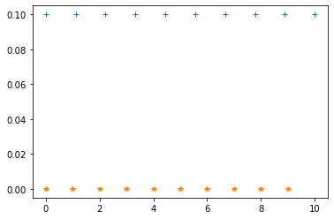

```python
import numpy as np
import matplotlib.pyplot as plt

y=np.zeros(10)
x1=np.linspace(0,10,10,False)
x2=np.linspace(0,10,10,True)
plt.plot(x2, y+0.1, '+')
plt.plot(x1,y,'*')
plt.show()
```

#### 얕은 복사 깊은 복사

```python
t1=np.array([10,20,30,40,50])
t2= t1[1:3]

t2[0]=100
print(t1)
```

```
[ 10 100  30  40  50]
```

```python
t1=np.array([10,20,30,40,50])
t2= t1[1:3].copy()

t2[0]=100
print(t1)
```

```
[10 20 30 40 50]
```

```python
import numpy as np

a=np.arange(12).reshape(3,4)

a[2]=100
print(a)
```

```
[[  0   1   2   3]
 [  4   5   6   7]
 [100 100 100 100]]
```

```python
a=np.arange(12).reshape(3,4)

a[1][2]=1000
print(a)
```

```
[[   0    1    2    3]
 [   4    5 1000    7]
 [   8    9   10   11]]
```

#### 배열 통계 메서드

https://numpy.org/doc/stable/reference/routines.statistics.html

sum : 모든 원소의 합

min: 최소값

max: 최대값

mean : 산술평균

std : 표준편차

var: 분산 , std의 제곱

cumsum : 누적합

2차원 배열에서 np.sum( , axis=0) : x축으로의 합산( x축에 있는 내용을 합산)  
=>y축값이 보여줌

axis=1 : y축으로의 계산 => y축에 있는 전부를 합산 =>x 보여줌

각 컬럼 (열) axis=1 : 각 로우(행)

[figure not shown]

```python
b=np.array(np.arange(6)).reshape(3,2)
print(b)
```

```
[[0 1]
 [2 3]
 [4 5]]
```

[figure not shown]

np.array(np.arange(6)).reshape(3,2)는 0~5를 3행 2열로 배치

(x, y)에서 axis=0은 x값으로의 합산

```python
b.sum(axis=0) # sum of each column array
```

```
array([6, 9])
```

```python
b.sum(axis=1)  # sum of each row
```

```
array([1, 5, 9])
```

```python
b.min(axis=1) # min of each row array
```

```
array([0, 2, 4])
```

```python
b.min(axis=0)
```

```
array([0, 1])
```

```python
b.cumsum(axis=1) #누적값
```

```
array([[0, 1],
       [2, 5],
       [4, 9]], dtype=int32)
```

#### 결측치(missing value)를 제거하고 사용하는 함수

np.nanmin, np.nanmean 등

```python
a = np.array([[1, 2], [3, np.nan]])  #결측치(missing value :np.nam)을 제거하고 min
np.nanmin(a)
```

```
1.0
```

```python
np.nanmin(a, axis=0)
```

```
array([1., 2.])
```

```python
np.nanmin(a, axis=1)
```

```
array([1., 3.])
```

```python
np.nanmean(a)  #결측치(missing value)을 제거하고 평균
```

```
2.0
```

#### ptp (최대값과 최소값의 범위)

https://numpy.org/doc/stable/reference/generated/numpy.ptp.html  
numpy.ptp(a, axis=None, out=None, keepdims=)  
Range of values (maximum - minimum) along an axis.

```python
import numpy as np
x = np.array([[4, 9, 2, 10],
              [6, 9, 7, 12]])

np.ptp(x, axis=0)
```

```
array([2, 0, 5, 2])
```

```python
np.ptp(x, axis=1)
```

```
array([8, 6])
```

#### percentile : 백분위수 : 1~100을 기준으로

numpy.percentile(a, q, axis=None, out=None, overwrite_input=False, interpolation='linear', keepdims=False)  
Compute the q-th percentile of the data along the specified axis.

```python
a = np.array([10, 7, 4, 3, 2, 1])
np.percentile(a, 50)
```

```
3.5
```

```python
a=np.array([[10,7,4],[3,2,1]])
np.percentile(a, 50, axis=0)
```

```
array([6.5, 4.5, 2.5])
```

```python
a=np.arange(25).reshape(5,5)
print(a)
np.percentile(a, 25, axis=0)
```

```
[[ 0  1  2  3  4]
 [ 5  6  7  8  9]
 [10 11 12 13 14]
 [15 16 17 18 19]
 [20 21 22 23 24]]
```

```
array([5., 6., 7., 8., 9.])
```

#### quantile : numpy.quantile(a, q, axis=None, out=None, overwrite_input=False, interpolation='linear', keepdims=False)

https://numpy.org/doc/stable/reference/generated/numpy.quantile.html?highlight=quantile#numpy.quantile

Compute the q-th quantile of the data along the specified axis.

percentile : equivalent to quantile, but with q in the range [0, 100].

median :equivalent to quantile(..., 0.5)

```python
a = np.array([[10, 7, 4], [3, 2, 1]])  # 1 2 3 4 7 10 의 중앙값  0~1까지에서
np.quantile(a, 0.5)
```

```
3.5
```